# Plastics_Jan2018_DADA2

Winston Liu

February 06, 2020

# DESCRIPTION OF DATA (from Josh):

This data set is a duplicated time series of the microbiomes on 7 different kinds of recycle plastics that were simultaneously exposed for 70 days to running sea watet and then sampled on day 8, 16, 24, 32 and 70. The idea is to use the microbiomes as a tool to figure out the nature of the additives in plastics by comparing them to microbiomes growing on toxic coatings and other coatings in marine environments. The initial question is: How do the communities change with time and can we tell the plastics apart?

## Data storage

Downloaded from dds into /sharedspace/oysters/plastics Based on the Order_4860_Notes.rtf, it seems that “1st MiSeq run did not perform to specifications so they ran it a 2nd time and gave us both sets of data.” So will proceed with the data from Order 4860?

#Libraries

```r
library(readr)
library(readxl)
library(fs)
library(R.utils)
library(tidyverse)
library(stringr)
library(phyloseq)
library(ggplot2)
library(dada2)
library(magrittr)
```

# INPUTS

Folder names:

```r
baseFolder <- "/sharedspace/oysters/plastics/rittschof/RawDataJan2018_4522"
excelFile <- "/sharedspace/oysters/plastics/rittschof/sample_sheet_order_4522.xls"

outputFiltered <- "/sharedspace/oysters/plastics/scratch/filtered_Jan2018"
output.dir <- "/sharedspace/oysters/plastics/output"
ps.file <- file.path(output.dir,"ps_plastics_Jan2018.rds")
track.file <- file.path(output.dir,"track_track_Jan2018.rds")
```

Read in the files:

```r
run.files <- list.files(baseFolder, pattern = "R1_001.fastq.gz")
sampleTable <- read_xls(excelFile, skip = 3)
```

```
## * `` -> ...2
## * `` -> ...3
## * `` -> ...4
## * `` -> ...5
## * `` -> ...6
## * … and 10 more problems
```

```r
matchtable <- sampleTable[,c(1,16)]
colnames(matchtable) <- c("sampleName","sampleID")
```

# SAMPLE TABLE

```r
R1.fileName <- run.files
R2.fileName <- str_replace(run.files,"R1","R2")

run.files %>%
  as_tibble %>%
  separate(value, into=c("sampleName"),sep="_") %>%
  mutate(R1.fileName = R1.fileName, R2.fileName = R2.fileName) ->
  sampleInfo
sampleInfo %<>%
  left_join(matchtable) %>%
  separate(sampleID, into = c("plasticType","dayNum"),sep = "-", remove = FALSE)
sampleInfo
```

[output not shown]

# View quality profiles

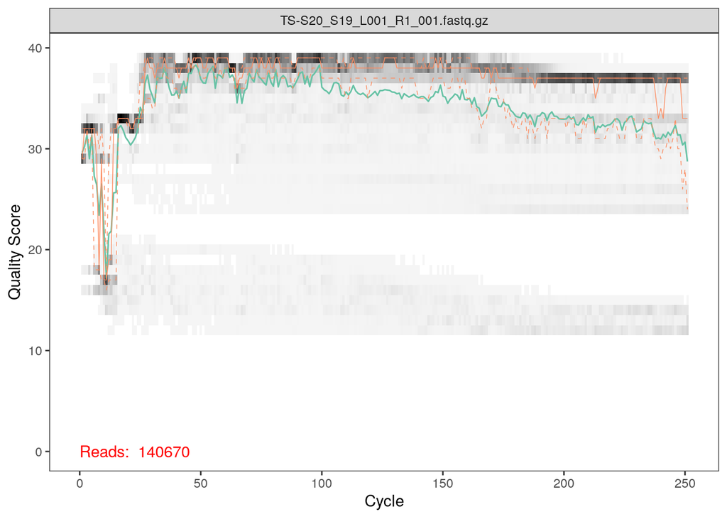

```r
i<-12
plotQualityProfile(file.path(baseFolder, sampleInfo$R1.fileName[i]))
```

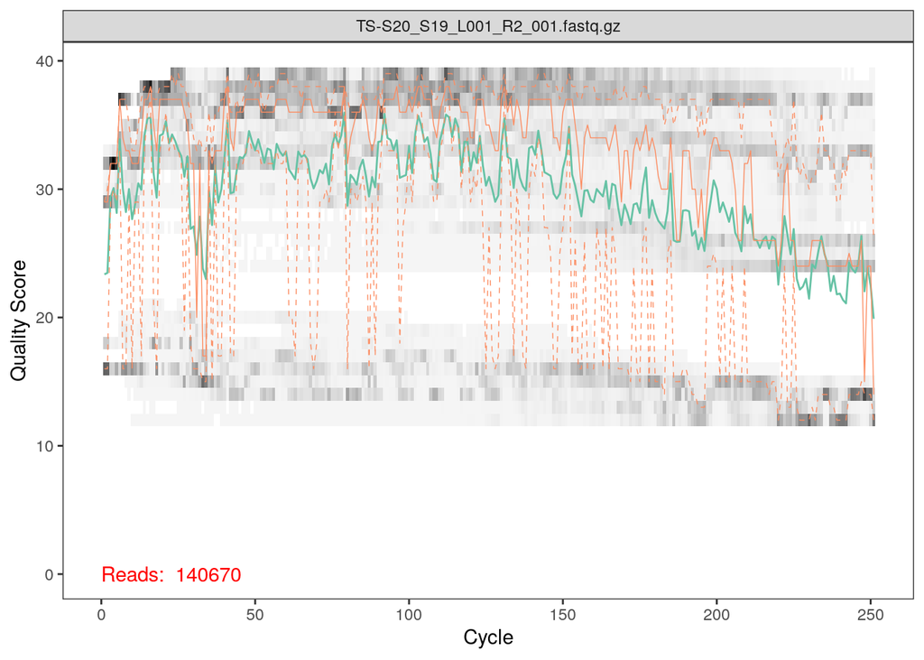

```r
plotQualityProfile(file.path(baseFolder, sampleInfo$R2.fileName[i]))
```

# Perform filtering and trimming

### Generate filenames for the filtered fastq.gz files.

You need to use the names of the raw (demultiplexed) FASTQ files to generate a vector of names for the filtered FASTQs. You need separate vectors for the forward and reverse reads. It is a very good idea to put all the filtered FASTQs in their own directory.

```r
filtFs <- file.path(outputFiltered , paste0(sampleInfo$sampleName, "_F_filt.fastq.gz"))
filtRs <- file.path(outputFiltered , paste0(sampleInfo$sampleName, "_R_filt.fastq.gz"))
fnFs <- file.path(baseFolder,as.character(sampleInfo$R1.fileName))
fnRs <- file.path(baseFolder,as.character(sampleInfo$R2.fileName))
```

### Filter the forward and reverse reads

Now let’s do the filtering using the parameters we chose based on the quality plots

```r
filt.out <- filterAndTrim(fwd = fnFs, filt = filtFs, rev = fnRs, filt.rev = filtRs, trimLeft=10, truncLen=c(245,225),
              maxN=0, maxEE=c(2,2), truncQ=2, rm.phix=TRUE,
              compress=TRUE, multithread=FALSE) # On Windows set multithread=FALSE
```

```
## Creating output directory: /sharedspace/oysters/plastics/scratch/filtered_Jan2018
```

```r
filt.out
```

```
##                                 reads.in reads.out
## TS-S1_S1_L001_R1_001.fastq.gz     300105    223442
## TS-S10_S10_L001_R1_001.fastq.gz   239403    183277
## TS-S11_S11_L001_R1_001.fastq.gz   221510    176573
## TS-S12_S12_L001_R1_001.fastq.gz   155106    109220
## TS-S13_S13_L001_R1_001.fastq.gz   334745    265745
## TS-S14_S14_L001_R1_001.fastq.gz   292338    231334
## TS-S15_S15_L001_R1_001.fastq.gz   188435    150371
## TS-S17_S16_L001_R1_001.fastq.gz   244664    169869
## TS-S18_S17_L001_R1_001.fastq.gz   284018    210251
## TS-S19_S18_L001_R1_001.fastq.gz   321681    246758
## TS-S2_S2_L001_R1_001.fastq.gz     393557    291047
## TS-S20_S19_L001_R1_001.fastq.gz   140670     86600
## TS-S21_S20_L001_R1_001.fastq.gz   186813    155266
## TS-S22_S21_L001_R1_001.fastq.gz   200960    164523
## TS-S23_S22_L001_R1_001.fastq.gz   155952    130279
## TS-S24_S23_L001_R1_001.fastq.gz    77701     62613
## TS-S25_S24_L001_R1_001.fastq.gz   203977    164144
## TS-S26_S25_L001_R1_001.fastq.gz   272994    222503
## TS-S27_S26_L001_R1_001.fastq.gz   158242    129523
## TS-S28_S27_L001_R1_001.fastq.gz   138941    110655
## TS-S29_S28_L001_R1_001.fastq.gz   278390    227591
## TS-S3_S3_L001_R1_001.fastq.gz     356591    283378
## TS-S30_S29_L001_R1_001.fastq.gz   258317    208272
## TS-S31_S30_L001_R1_001.fastq.gz   231791    187269
## TS-S32_S31_L001_R1_001.fastq.gz   145015    113428
## TS-S33_S32_L001_R1_001.fastq.gz   270762    219708
## TS-S34_S33_L001_R1_001.fastq.gz   319496    260209
## TS-S35_S34_L001_R1_001.fastq.gz   298384    243585
## TS-S36_S35_L001_R1_001.fastq.gz   153904    124314
## TS-S37_S36_L001_R1_001.fastq.gz   335462    277410
## TS-S38_S37_L001_R1_001.fastq.gz   287729    234108
## TS-S39_S38_L001_R1_001.fastq.gz   293017    237093
## TS-S4_S4_L001_R1_001.fastq.gz     197939    135610
## TS-S5_S5_L001_R1_001.fastq.gz     344814    267884
## TS-S6_S6_L001_R1_001.fastq.gz     370641    288168
## TS-S7_S7_L001_R1_001.fastq.gz     296209    230985
## TS-S8_S8_L001_R1_001.fastq.gz     346979    257019
## TS-S9_S9_L001_R1_001.fastq.gz     203869    152370
```

### Tweak Filtered FASTQ list

```r
filtFs <- filtFs[file_exists(filtFs)]
filtRs <- filtRs[file_exists(filtRs)]
sample.names <- filtFs  %>%
  basename %>%
  str_replace("_F_filt.fastq.gz","")
```

## Learn the Error Rates

With that bit of cleanup done, we are ready to build an error model from the filtered FASTQs. We do this seperately for the R1 and R2 FASTQs, since they have different patterns of errors, as we have seen.

```r
errF <- learnErrors(filtFs, multithread=TRUE)
```

```
## 137073620 total bases in 583292 reads from 3 samples will be used for learning the error rates.
```

```r
errR <- learnErrors(filtRs, multithread=TRUE)
```

```
## 125407780 total bases in 583292 reads from 3 samples will be used for learning the error rates.
```

It is always worthwhile, as a sanity check if nothing else, to visualize the estimated error rates:

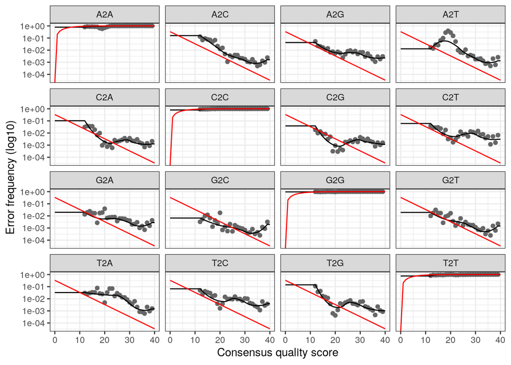

```r
plotErrors(errF, nominalQ=TRUE)
```

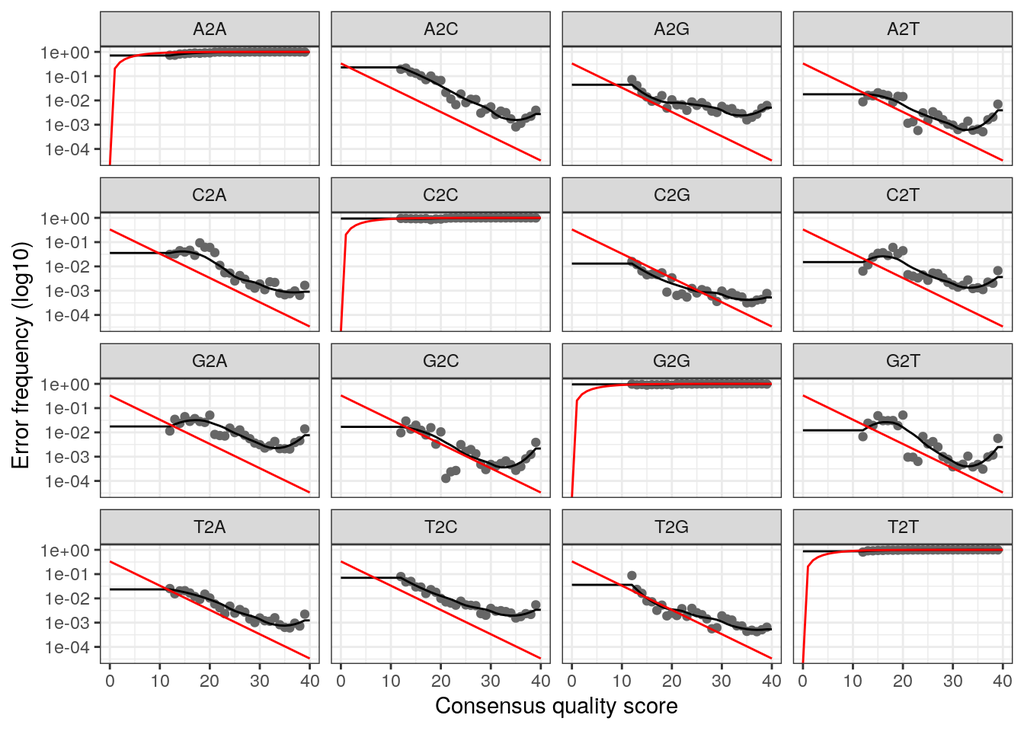

```r
plotErrors(errR, nominalQ=TRUE)
```

The error rates for each possible transition (eg. A->C, A->G, …) are shown. Points are the observed error rates for each consensus quality score. The black line shows the estimated error rates after convergence. The red line shows the error rates expected under the nominal definition of the Q-value. Here the black line (the estimated rates) fits the observed rates well, and the error rates drop with increased quality as expected.

Since we are using a small subset of the data, the learned error rates might look funny. This is OK for now, since we are just doing a pilot analysis.

## Dereplication

Dereplication combines all identical sequencing reads into “unique sequences” with a corresponding “abundance” tally: the number of reads with that unique sequence. Dereplication substantially reduces computation time for the inference step, since we only need to do inference for unique sequences.

```r
derepFs <- derepFastq(filtFs, verbose=TRUE)
```

```
## Dereplicating sequence entries in Fastq file: /sharedspace/oysters/plastics/scratch/filtered_Jan2018/TS-S1_F_filt.fastq.gz
```

```
## Encountered 74052 unique sequences from 223442 total sequences read.
```

```
## Dereplicating sequence entries in Fastq file: /sharedspace/oysters/plastics/scratch/filtered_Jan2018/TS-S10_F_filt.fastq.gz
```

```
## Encountered 50626 unique sequences from 183277 total sequences read.
```

```
## Dereplicating sequence entries in Fastq file: /sharedspace/oysters/plastics/scratch/filtered_Jan2018/TS-S11_F_filt.fastq.gz
```

```
## Encountered 37088 unique sequences from 176573 total sequences read.
```

```
## Dereplicating sequence entries in Fastq file: /sharedspace/oysters/plastics/scratch/filtered_Jan2018/TS-S12_F_filt.fastq.gz
```

```
## Encountered 32058 unique sequences from 109220 total sequences read.
```

```
## Dereplicating sequence entries in Fastq file: /sharedspace/oysters/plastics/scratch/filtered_Jan2018/TS-S13_F_filt.fastq.gz
```

```
## Encountered 73449 unique sequences from 265745 total sequences read.
```

```
## Dereplicating sequence entries in Fastq file: /sharedspace/oysters/plastics/scratch/filtered_Jan2018/TS-S14_F_filt.fastq.gz
```

```
## Encountered 62364 unique sequences from 231334 total sequences read.
```

```
## Dereplicating sequence entries in Fastq file: /sharedspace/oysters/plastics/scratch/filtered_Jan2018/TS-S15_F_filt.fastq.gz
```

```
## Encountered 32395 unique sequences from 150371 total sequences read.
```

```
## Dereplicating sequence entries in Fastq file: /sharedspace/oysters/plastics/scratch/filtered_Jan2018/TS-S17_F_filt.fastq.gz
```

```
## Encountered 44409 unique sequences from 169869 total sequences read.
```

```
## Dereplicating sequence entries in Fastq file: /sharedspace/oysters/plastics/scratch/filtered_Jan2018/TS-S18_F_filt.fastq.gz
```

```
## Encountered 37667 unique sequences from 210251 total sequences read.
```

```
## Dereplicating sequence entries in Fastq file: /sharedspace/oysters/plastics/scratch/filtered_Jan2018/TS-S19_F_filt.fastq.gz
```

```
## Encountered 45122 unique sequences from 246758 total sequences read.
```

```
## Dereplicating sequence entries in Fastq file: /sharedspace/oysters/plastics/scratch/filtered_Jan2018/TS-S2_F_filt.fastq.gz
```

```
## Encountered 93614 unique sequences from 291047 total sequences read.
```

```
## Dereplicating sequence entries in Fastq file: /sharedspace/oysters/plastics/scratch/filtered_Jan2018/TS-S20_F_filt.fastq.gz
```

```
## Encountered 22066 unique sequences from 86600 total sequences read.
```

```
## Dereplicating sequence entries in Fastq file: /sharedspace/oysters/plastics/scratch/filtered_Jan2018/TS-S21_F_filt.fastq.gz
```

```
## Encountered 36421 unique sequences from 155266 total sequences read.
```

```
## Dereplicating sequence entries in Fastq file: /sharedspace/oysters/plastics/scratch/filtered_Jan2018/TS-S22_F_filt.fastq.gz
```

```
## Encountered 41564 unique sequences from 164523 total sequences read.
```

```
## Dereplicating sequence entries in Fastq file: /sharedspace/oysters/plastics/scratch/filtered_Jan2018/TS-S23_F_filt.fastq.gz
```

```
## Encountered 26589 unique sequences from 130279 total sequences read.
```

```
## Dereplicating sequence entries in Fastq file: /sharedspace/oysters/plastics/scratch/filtered_Jan2018/TS-S24_F_filt.fastq.gz
```

```
## Encountered 12063 unique sequences from 62613 total sequences read.
```

```
## Dereplicating sequence entries in Fastq file: /sharedspace/oysters/plastics/scratch/filtered_Jan2018/TS-S25_F_filt.fastq.gz
```

```
## Encountered 45701 unique sequences from 164144 total sequences read.
```

```
## Dereplicating sequence entries in Fastq file: /sharedspace/oysters/plastics/scratch/filtered_Jan2018/TS-S26_F_filt.fastq.gz
```

```
## Encountered 49067 unique sequences from 222503 total sequences read.
```

```
## Dereplicating sequence entries in Fastq file: /sharedspace/oysters/plastics/scratch/filtered_Jan2018/TS-S27_F_filt.fastq.gz
```

```
## Encountered 26057 unique sequences from 129523 total sequences read.
```

```
## Dereplicating sequence entries in Fastq file: /sharedspace/oysters/plastics/scratch/filtered_Jan2018/TS-S28_F_filt.fastq.gz
```

```
## Encountered 28061 unique sequences from 110655 total sequences read.
```

```
## Dereplicating sequence entries in Fastq file: /sharedspace/oysters/plastics/scratch/filtered_Jan2018/TS-S29_F_filt.fastq.gz
```

```
## Encountered 53425 unique sequences from 227591 total sequences read.
```

```
## Dereplicating sequence entries in Fastq file: /sharedspace/oysters/plastics/scratch/filtered_Jan2018/TS-S3_F_filt.fastq.gz
```

```
## Encountered 53952 unique sequences from 283378 total sequences read.
```

```
## Dereplicating sequence entries in Fastq file: /sharedspace/oysters/plastics/scratch/filtered_Jan2018/TS-S30_F_filt.fastq.gz
```

```
## Encountered 47080 unique sequences from 208272 total sequences read.
```

```
## Dereplicating sequence entries in Fastq file: /sharedspace/oysters/plastics/scratch/filtered_Jan2018/TS-S31_F_filt.fastq.gz
```

```
## Encountered 45406 unique sequences from 187269 total sequences read.
```

```
## Dereplicating sequence entries in Fastq file: /sharedspace/oysters/plastics/scratch/filtered_Jan2018/TS-S32_F_filt.fastq.gz
```

```
## Encountered 17356 unique sequences from 113428 total sequences read.
```

```
## Dereplicating sequence entries in Fastq file: /sharedspace/oysters/plastics/scratch/filtered_Jan2018/TS-S33_F_filt.fastq.gz
```

```
## Encountered 66174 unique sequences from 219708 total sequences read.
```

```
## Dereplicating sequence entries in Fastq file: /sharedspace/oysters/plastics/scratch/filtered_Jan2018/TS-S34_F_filt.fastq.gz
```

```
## Encountered 61615 unique sequences from 260209 total sequences read.
```

```
## Dereplicating sequence entries in Fastq file: /sharedspace/oysters/plastics/scratch/filtered_Jan2018/TS-S35_F_filt.fastq.gz
```

```
## Encountered 54225 unique sequences from 243585 total sequences read.
```

```
## Dereplicating sequence entries in Fastq file: /sharedspace/oysters/plastics/scratch/filtered_Jan2018/TS-S36_F_filt.fastq.gz
```

```
## Encountered 28169 unique sequences from 124314 total sequences read.
```

```
## Dereplicating sequence entries in Fastq file: /sharedspace/oysters/plastics/scratch/filtered_Jan2018/TS-S37_F_filt.fastq.gz
```

```
## Encountered 62327 unique sequences from 277410 total sequences read.
```

```
## Dereplicating sequence entries in Fastq file: /sharedspace/oysters/plastics/scratch/filtered_Jan2018/TS-S38_F_filt.fastq.gz
```

```
## Encountered 48794 unique sequences from 234108 total sequences read.
```

```
## Dereplicating sequence entries in Fastq file: /sharedspace/oysters/plastics/scratch/filtered_Jan2018/TS-S39_F_filt.fastq.gz
```

```
## Encountered 54795 unique sequences from 237093 total sequences read.
```

```
## Dereplicating sequence entries in Fastq file: /sharedspace/oysters/plastics/scratch/filtered_Jan2018/TS-S4_F_filt.fastq.gz
```

```
## Encountered 44262 unique sequences from 135610 total sequences read.
```

```
## Dereplicating sequence entries in Fastq file: /sharedspace/oysters/plastics/scratch/filtered_Jan2018/TS-S5_F_filt.fastq.gz
```

```
## Encountered 89382 unique sequences from 267884 total sequences read.
```

```
## Dereplicating sequence entries in Fastq file: /sharedspace/oysters/plastics/scratch/filtered_Jan2018/TS-S6_F_filt.fastq.gz
```

```
## Encountered 90036 unique sequences from 288168 total sequences read.
```

```
## Dereplicating sequence entries in Fastq file: /sharedspace/oysters/plastics/scratch/filtered_Jan2018/TS-S7_F_filt.fastq.gz
```

```
## Encountered 63145 unique sequences from 230985 total sequences read.
```

```
## Dereplicating sequence entries in Fastq file: /sharedspace/oysters/plastics/scratch/filtered_Jan2018/TS-S8_F_filt.fastq.gz
```

```
## Encountered 66010 unique sequences from 257019 total sequences read.
```

```
## Dereplicating sequence entries in Fastq file: /sharedspace/oysters/plastics/scratch/filtered_Jan2018/TS-S9_F_filt.fastq.gz
```

```
## Encountered 47170 unique sequences from 152370 total sequences read.
```

```r
derepRs <- derepFastq(filtRs, verbose=TRUE)
```

```
## Dereplicating sequence entries in Fastq file: /sharedspace/oysters/plastics/scratch/filtered_Jan2018/TS-S1_R_filt.fastq.gz
```

```
## Encountered 102575 unique sequences from 223442 total sequences read.
```

```
## Dereplicating sequence entries in Fastq file: /sharedspace/oysters/plastics/scratch/filtered_Jan2018/TS-S10_R_filt.fastq.gz
```

```
## Encountered 75085 unique sequences from 183277 total sequences read.
```

```
## Dereplicating sequence entries in Fastq file: /sharedspace/oysters/plastics/scratch/filtered_Jan2018/TS-S11_R_filt.fastq.gz
```

```
## Encountered 54543 unique sequences from 176573 total sequences read.
```

```
## Dereplicating sequence entries in Fastq file: /sharedspace/oysters/plastics/scratch/filtered_Jan2018/TS-S12_R_filt.fastq.gz
```

```
## Encountered 58376 unique sequences from 109220 total sequences read.
```

```
## Dereplicating sequence entries in Fastq file: /sharedspace/oysters/plastics/scratch/filtered_Jan2018/TS-S13_R_filt.fastq.gz
```

```
## Encountered 102304 unique sequences from 265745 total sequences read.
```

```
## Dereplicating sequence entries in Fastq file: /sharedspace/oysters/plastics/scratch/filtered_Jan2018/TS-S14_R_filt.fastq.gz
```

```
## Encountered 82900 unique sequences from 231334 total sequences read.
```

```
## Dereplicating sequence entries in Fastq file: /sharedspace/oysters/plastics/scratch/filtered_Jan2018/TS-S15_R_filt.fastq.gz
```

```
## Encountered 54368 unique sequences from 150371 total sequences read.
```

```
## Dereplicating sequence entries in Fastq file: /sharedspace/oysters/plastics/scratch/filtered_Jan2018/TS-S17_R_filt.fastq.gz
```

```
## Encountered 91956 unique sequences from 169869 total sequences read.
```

```
## Dereplicating sequence entries in Fastq file: /sharedspace/oysters/plastics/scratch/filtered_Jan2018/TS-S18_R_filt.fastq.gz
```

```
## Encountered 82876 unique sequences from 210251 total sequences read.
```

```
## Dereplicating sequence entries in Fastq file: /sharedspace/oysters/plastics/scratch/filtered_Jan2018/TS-S19_R_filt.fastq.gz
```

```
## Encountered 92957 unique sequences from 246758 total sequences read.
```

```
## Dereplicating sequence entries in Fastq file: /sharedspace/oysters/plastics/scratch/filtered_Jan2018/TS-S2_R_filt.fastq.gz
```

```
## Encountered 120852 unique sequences from 291047 total sequences read.
```

```
## Dereplicating sequence entries in Fastq file: /sharedspace/oysters/plastics/scratch/filtered_Jan2018/TS-S20_R_filt.fastq.gz
```

```
## Encountered 50614 unique sequences from 86600 total sequences read.
```

```
## Dereplicating sequence entries in Fastq file: /sharedspace/oysters/plastics/scratch/filtered_Jan2018/TS-S21_R_filt.fastq.gz
```

```
## Encountered 44656 unique sequences from 155266 total sequences read.
```

```
## Dereplicating sequence entries in Fastq file: /sharedspace/oysters/plastics/scratch/filtered_Jan2018/TS-S22_R_filt.fastq.gz
```

```
## Encountered 47581 unique sequences from 164523 total sequences read.
```

```
## Dereplicating sequence entries in Fastq file: /sharedspace/oysters/plastics/scratch/filtered_Jan2018/TS-S23_R_filt.fastq.gz
```

```
## Encountered 34777 unique sequences from 130279 total sequences read.
```

```
## Dereplicating sequence entries in Fastq file: /sharedspace/oysters/plastics/scratch/filtered_Jan2018/TS-S24_R_filt.fastq.gz
```

```
## Encountered 12563 unique sequences from 62613 total sequences read.
```

```
## Dereplicating sequence entries in Fastq file: /sharedspace/oysters/plastics/scratch/filtered_Jan2018/TS-S25_R_filt.fastq.gz
```

```
## Encountered 59681 unique sequences from 164144 total sequences read.
```

```
## Dereplicating sequence entries in Fastq file: /sharedspace/oysters/plastics/scratch/filtered_Jan2018/TS-S26_R_filt.fastq.gz
```

```
## Encountered 54588 unique sequences from 222503 total sequences read.
```

```
## Dereplicating sequence entries in Fastq file: /sharedspace/oysters/plastics/scratch/filtered_Jan2018/TS-S27_R_filt.fastq.gz
```

```
## Encountered 27933 unique sequences from 129523 total sequences read.
```

```
## Dereplicating sequence entries in Fastq file: /sharedspace/oysters/plastics/scratch/filtered_Jan2018/TS-S28_R_filt.fastq.gz
```

```
## Encountered 41714 unique sequences from 110655 total sequences read.
```

```
## Dereplicating sequence entries in Fastq file: /sharedspace/oysters/plastics/scratch/filtered_Jan2018/TS-S29_R_filt.fastq.gz
```

```
## Encountered 71291 unique sequences from 227591 total sequences read.
```

```
## Dereplicating sequence entries in Fastq file: /sharedspace/oysters/plastics/scratch/filtered_Jan2018/TS-S3_R_filt.fastq.gz
```

```
## Encountered 76366 unique sequences from 283378 total sequences read.
```

```
## Dereplicating sequence entries in Fastq file: /sharedspace/oysters/plastics/scratch/filtered_Jan2018/TS-S30_R_filt.fastq.gz
```

```
## Encountered 61064 unique sequences from 208272 total sequences read.
```

```
## Dereplicating sequence entries in Fastq file: /sharedspace/oysters/plastics/scratch/filtered_Jan2018/TS-S31_R_filt.fastq.gz
```

```
## Encountered 64949 unique sequences from 187269 total sequences read.
```

```
## Dereplicating sequence entries in Fastq file: /sharedspace/oysters/plastics/scratch/filtered_Jan2018/TS-S32_R_filt.fastq.gz
```

```
## Encountered 24021 unique sequences from 113428 total sequences read.
```

```
## Dereplicating sequence entries in Fastq file: /sharedspace/oysters/plastics/scratch/filtered_Jan2018/TS-S33_R_filt.fastq.gz
```

```
## Encountered 79592 unique sequences from 219708 total sequences read.
```

```
## Dereplicating sequence entries in Fastq file: /sharedspace/oysters/plastics/scratch/filtered_Jan2018/TS-S34_R_filt.fastq.gz
```

```
## Encountered 69010 unique sequences from 260209 total sequences read.
```

```
## Dereplicating sequence entries in Fastq file: /sharedspace/oysters/plastics/scratch/filtered_Jan2018/TS-S35_R_filt.fastq.gz
```

```
## Encountered 54648 unique sequences from 243585 total sequences read.
```

```
## Dereplicating sequence entries in Fastq file: /sharedspace/oysters/plastics/scratch/filtered_Jan2018/TS-S36_R_filt.fastq.gz
```

```
## Encountered 45854 unique sequences from 124314 total sequences read.
```

```
## Dereplicating sequence entries in Fastq file: /sharedspace/oysters/plastics/scratch/filtered_Jan2018/TS-S37_R_filt.fastq.gz
```

```
## Encountered 71477 unique sequences from 277410 total sequences read.
```

```
## Dereplicating sequence entries in Fastq file: /sharedspace/oysters/plastics/scratch/filtered_Jan2018/TS-S38_R_filt.fastq.gz
```

```
## Encountered 58039 unique sequences from 234108 total sequences read.
```

```
## Dereplicating sequence entries in Fastq file: /sharedspace/oysters/plastics/scratch/filtered_Jan2018/TS-S39_R_filt.fastq.gz
```

```
## Encountered 65045 unique sequences from 237093 total sequences read.
```

```
## Dereplicating sequence entries in Fastq file: /sharedspace/oysters/plastics/scratch/filtered_Jan2018/TS-S4_R_filt.fastq.gz
```

```
## Encountered 75223 unique sequences from 135610 total sequences read.
```

```
## Dereplicating sequence entries in Fastq file: /sharedspace/oysters/plastics/scratch/filtered_Jan2018/TS-S5_R_filt.fastq.gz
```

```
## Encountered 96468 unique sequences from 267884 total sequences read.
```

```
## Dereplicating sequence entries in Fastq file: /sharedspace/oysters/plastics/scratch/filtered_Jan2018/TS-S6_R_filt.fastq.gz
```

```
## Encountered 96749 unique sequences from 288168 total sequences read.
```

```
## Dereplicating sequence entries in Fastq file: /sharedspace/oysters/plastics/scratch/filtered_Jan2018/TS-S7_R_filt.fastq.gz
```

```
## Encountered 72097 unique sequences from 230985 total sequences read.
```

```
## Dereplicating sequence entries in Fastq file: /sharedspace/oysters/plastics/scratch/filtered_Jan2018/TS-S8_R_filt.fastq.gz
```

```
## Encountered 60073 unique sequences from 257019 total sequences read.
```

```
## Dereplicating sequence entries in Fastq file: /sharedspace/oysters/plastics/scratch/filtered_Jan2018/TS-S9_R_filt.fastq.gz
```

```
## Encountered 75962 unique sequences from 152370 total sequences read.
```

### Rename derep objects

`derepFastq` returns a list of derep objects that are named based on the input filename. For later steps it is going to be more convenient if each derep object is named with just it’s sample name, so let’s rename the derep objects using the sample name vector that we created earlier.

```r
names(derepFs) <- sampleInfo$sampleName
names(derepRs) <- sampleInfo$sampleName
```

## Sample Inference

Now you need to infer the true sequences from the dereplicated data.

```r
dadaFs <- dada(derepFs, err=errF, multithread=TRUE)
```

```
## Sample 1 - 223442 reads in 74052 unique sequences.
## Sample 2 - 183277 reads in 50626 unique sequences.
## Sample 3 - 176573 reads in 37088 unique sequences.
## Sample 4 - 109220 reads in 32058 unique sequences.
## Sample 5 - 265745 reads in 73449 unique sequences.
## Sample 6 - 231334 reads in 62364 unique sequences.
## Sample 7 - 150371 reads in 32395 unique sequences.
## Sample 8 - 169869 reads in 44409 unique sequences.
## Sample 9 - 210251 reads in 37667 unique sequences.
## Sample 10 - 246758 reads in 45122 unique sequences.
## Sample 11 - 291047 reads in 93614 unique sequences.
## Sample 12 - 86600 reads in 22066 unique sequences.
## Sample 13 - 155266 reads in 36421 unique sequences.
## Sample 14 - 164523 reads in 41564 unique sequences.
## Sample 15 - 130279 reads in 26589 unique sequences.
## Sample 16 - 62613 reads in 12063 unique sequences.
## Sample 17 - 164144 reads in 45701 unique sequences.
## Sample 18 - 222503 reads in 49067 unique sequences.
## Sample 19 - 129523 reads in 26057 unique sequences.
## Sample 20 - 110655 reads in 28061 unique sequences.
## Sample 21 - 227591 reads in 53425 unique sequences.
## Sample 22 - 283378 reads in 53952 unique sequences.
## Sample 23 - 208272 reads in 47080 unique sequences.
## Sample 24 - 187269 reads in 45406 unique sequences.
## Sample 25 - 113428 reads in 17356 unique sequences.
## Sample 26 - 219708 reads in 66174 unique sequences.
## Sample 27 - 260209 reads in 61615 unique sequences.
## Sample 28 - 243585 reads in 54225 unique sequences.
## Sample 29 - 124314 reads in 28169 unique sequences.
## Sample 30 - 277410 reads in 62327 unique sequences.
## Sample 31 - 234108 reads in 48794 unique sequences.
## Sample 32 - 237093 reads in 54795 unique sequences.
## Sample 33 - 135610 reads in 44262 unique sequences.
## Sample 34 - 267884 reads in 89382 unique sequences.
## Sample 35 - 288168 reads in 90036 unique sequences.
## Sample 36 - 230985 reads in 63145 unique sequences.
## Sample 37 - 257019 reads in 66010 unique sequences.
## Sample 38 - 152370 reads in 47170 unique sequences.
```

```r
dadaRs <- dada(derepRs, err=errR, multithread=TRUE)
```

```
## Sample 1 - 223442 reads in 102575 unique sequences.
## Sample 2 - 183277 reads in 75085 unique sequences.
## Sample 3 - 176573 reads in 54543 unique sequences.
## Sample 4 - 109220 reads in 58376 unique sequences.
## Sample 5 - 265745 reads in 102304 unique sequences.
## Sample 6 - 231334 reads in 82900 unique sequences.
## Sample 7 - 150371 reads in 54368 unique sequences.
## Sample 8 - 169869 reads in 91956 unique sequences.
## Sample 9 - 210251 reads in 82876 unique sequences.
## Sample 10 - 246758 reads in 92957 unique sequences.
## Sample 11 - 291047 reads in 120852 unique sequences.
## Sample 12 - 86600 reads in 50614 unique sequences.
## Sample 13 - 155266 reads in 44656 unique sequences.
## Sample 14 - 164523 reads in 47581 unique sequences.
## Sample 15 - 130279 reads in 34777 unique sequences.
## Sample 16 - 62613 reads in 12563 unique sequences.
## Sample 17 - 164144 reads in 59681 unique sequences.
## Sample 18 - 222503 reads in 54588 unique sequences.
## Sample 19 - 129523 reads in 27933 unique sequences.
## Sample 20 - 110655 reads in 41714 unique sequences.
## Sample 21 - 227591 reads in 71291 unique sequences.
## Sample 22 - 283378 reads in 76366 unique sequences.
## Sample 23 - 208272 reads in 61064 unique sequences.
## Sample 24 - 187269 reads in 64949 unique sequences.
## Sample 25 - 113428 reads in 24021 unique sequences.
## Sample 26 - 219708 reads in 79592 unique sequences.
## Sample 27 - 260209 reads in 69010 unique sequences.
## Sample 28 - 243585 reads in 54648 unique sequences.
## Sample 29 - 124314 reads in 45854 unique sequences.
## Sample 30 - 277410 reads in 71477 unique sequences.
## Sample 31 - 234108 reads in 58039 unique sequences.
## Sample 32 - 237093 reads in 65045 unique sequences.
## Sample 33 - 135610 reads in 75223 unique sequences.
## Sample 34 - 267884 reads in 96468 unique sequences.
## Sample 35 - 288168 reads in 96749 unique sequences.
## Sample 36 - 230985 reads in 72097 unique sequences.
## Sample 37 - 257019 reads in 60073 unique sequences.
## Sample 38 - 152370 reads in 75962 unique sequences.
```

## Merge paired reads

Each pair of R1 and R2 reads represents one observed sequence, so we ultimately need to combine them into a single sequence. The paired reads allows us to reduce sequence error where the reads overlap because that part of the insert has been sequenced twice so we can compare the two sequences and be sure they agree. This is why it is desireable to have reads that overlap as much as possible.

```r
mergers <- mergePairs(dadaFs, derepFs, dadaRs, derepRs, verbose=TRUE)
```

```
## 73589 paired-reads (in 2190 unique pairings) successfully merged out of 204078 (in 26875 pairings) input.
```

```
## 72640 paired-reads (in 1337 unique pairings) successfully merged out of 170747 (in 13144 pairings) input.
```

```
## 66574 paired-reads (in 812 unique pairings) successfully merged out of 170270 (in 7188 pairings) input.
```

```
## 31311 paired-reads (in 688 unique pairings) successfully merged out of 100621 (in 9632 pairings) input.
```

```
## 92880 paired-reads (in 1848 unique pairings) successfully merged out of 248187 (in 19958 pairings) input.
```

```
## 80043 paired-reads (in 1751 unique pairings) successfully merged out of 216909 (in 17353 pairings) input.
```

```
## 63131 paired-reads (in 960 unique pairings) successfully merged out of 146166 (in 5464 pairings) input.
```

```
## 75259 paired-reads (in 1246 unique pairings) successfully merged out of 158025 (in 14664 pairings) input.
```

```
## 113222 paired-reads (in 1025 unique pairings) successfully merged out of 203731 (in 8099 pairings) input.
```

```
## 83959 paired-reads (in 1176 unique pairings) successfully merged out of 239149 (in 10787 pairings) input.
```

```
## 101996 paired-reads (in 2682 unique pairings) successfully merged out of 269508 (in 27713 pairings) input.
```

```
## 29687 paired-reads (in 432 unique pairings) successfully merged out of 80275 (in 6382 pairings) input.
```

```
## 84634 paired-reads (in 1171 unique pairings) successfully merged out of 147030 (in 8824 pairings) input.
```

```
## 61972 paired-reads (in 1079 unique pairings) successfully merged out of 155456 (in 10133 pairings) input.
```

```
## 75287 paired-reads (in 890 unique pairings) successfully merged out of 125947 (in 5063 pairings) input.
```

```
## 8169 paired-reads (in 100 unique pairings) successfully merged out of 62100 (in 779 pairings) input.
```

```
## 68140 paired-reads (in 1318 unique pairings) successfully merged out of 153906 (in 13363 pairings) input.
```

```
## 117531 paired-reads (in 1544 unique pairings) successfully merged out of 215418 (in 10745 pairings) input.
```

```
## 52932 paired-reads (in 659 unique pairings) successfully merged out of 126199 (in 4335 pairings) input.
```

```
## 38066 paired-reads (in 626 unique pairings) successfully merged out of 105887 (in 7477 pairings) input.
```

```
## 115769 paired-reads (in 1959 unique pairings) successfully merged out of 217522 (in 14087 pairings) input.
```

```
## 49455 paired-reads (in 929 unique pairings) successfully merged out of 275820 (in 12297 pairings) input.
```

```
## 80047 paired-reads (in 1191 unique pairings) successfully merged out of 200383 (in 11701 pairings) input.
```

```
## 92215 paired-reads (in 1597 unique pairings) successfully merged out of 178401 (in 11176 pairings) input.
```

```
## 32395 paired-reads (in 94 unique pairings) successfully merged out of 112674 (in 724 pairings) input.
```

```
## 60004 paired-reads (in 1697 unique pairings) successfully merged out of 205958 (in 23868 pairings) input.
```

```
## 81360 paired-reads (in 1393 unique pairings) successfully merged out of 252293 (in 16601 pairings) input.
```

```
## 54644 paired-reads (in 1283 unique pairings) successfully merged out of 235274 (in 14590 pairings) input.
```

```
## 26859 paired-reads (in 539 unique pairings) successfully merged out of 120329 (in 8689 pairings) input.
```

```
## 105439 paired-reads (in 1617 unique pairings) successfully merged out of 270738 (in 14799 pairings) input.
```

```
## 50740 paired-reads (in 834 unique pairings) successfully merged out of 228293 (in 11281 pairings) input.
```

```
## 70209 paired-reads (in 1217 unique pairings) successfully merged out of 230133 (in 12355 pairings) input.
```

```
## 40260 paired-reads (in 1133 unique pairings) successfully merged out of 123981 (in 14417 pairings) input.
```

```
## 93092 paired-reads (in 2668 unique pairings) successfully merged out of 245883 (in 26573 pairings) input.
```

```
## 103429 paired-reads (in 2597 unique pairings) successfully merged out of 266890 (in 25308 pairings) input.
```

```
## 89616 paired-reads (in 1892 unique pairings) successfully merged out of 220658 (in 14358 pairings) input.
```

```
## 129575 paired-reads (in 2038 unique pairings) successfully merged out of 248902 (in 12919 pairings) input.
```

```
## 49902 paired-reads (in 1291 unique pairings) successfully merged out of 139013 (in 14397 pairings) input.
```

The results of `mergePairs` is a list of data frames with one data frame for each sample. Each data frame contains the unique merged sequences observed for that sample along with information about each sequence.

Paired reads that did not perfectly match in the overlapping region were removed by `mergePairs`.

## Construct sequence table

We can now construct a sequence table of our samples. This the equivalent of the OTU table produced by other methods. The sequence table has a row for each sample and a column for each ASV (the DADA2 equivalent of an OTU), with the count of the number of each ASV observed in each sample.

```r
seqtab <- makeSequenceTable(mergers)
```

```r
dim(seqtab)
```

```
## [1]    38 29020
```

Let’s check the size distribution of the ASVs we have inferred.

```r
table(nchar(getSequences(seqtab)))
```

```
##
##   235   236   237   238   239   240   241   242   243   244   245   246   247   248   249   250   251   252   253   254   255   256   257
##    21     1     3     3     6     3     3    33     4     2     2     3     1     3     2     2     1     5     1    37     7     1     3
##   258   259   261   262   263   264   265   266   267   268   269   270   272   273   274   275   277   278   279   280   281   282   283
##     3     1     7    33     1     1     3     6     2     2     6     1     1     2     4     3     2    37     5     2     2     3     1
##   284   285   286   287   289   290   291   292   293   296   297   298   299   300   301   303   305   306   307   308   309   310   311
##    53     2     6     2     4     1     1     1     2     1     1     1     1     3     2     6     1     2     1     1     2     1     1
##   312   313   314   315   316   317   318   321   322   323   324   326   330   331   332   333   334   335   336   337   340   341   343
##     3     2     4     4     3     2     5     3     6     3     3     1     3     2     2    62     1     2     1     2     2     1     2
##   344   345   346   348   349   351   352   353   356   357   358   359   360   361   362   363   366   367   368   373   374   375   376
##     4     3     4     1     5     2     8    12     2    19    19     1     4     1     5     4     5     3     7     2     1     1     1
##   377   378   379   382   383   384   385   386   387   389   390   391   392   393   395   396   397   398   399   400   401   402   403
##     6     2     3     1     5     2     7     2     1     2     5     8     7     1     1     5     2    11     7     7    13    21    74
##   404   405   406   407   408   409   411   412   413   414   415   416   417   418   419   420   421   422   423   424   425   426   427
##    23    21     6     3     7     4     2     2     6     5     2     9    13    63   389 18987  3035  1300  1474   732   436    99   102
##   428   429   430   431   432   433   434   435   436   437   438
##   101    57    44    55    30    41    55   258    34   103   725
```

## Remove chimeras

The core `dada` method removes substitution and indel errors, but chimeras remain. Fortunately, the accuracy of the sequences after denoising makes identifying chimeras simpler than it is when dealing with fuzzy OTUs: all sequences which can be exactly reconstructed as a bimera (two-parent chimera) from more abundant sequences. Let’s remove chimeric sequences

```r
seqtab.nochim <- removeBimeraDenovo(seqtab, method="consensus", multithread=TRUE, verbose=TRUE)
```

```
## Identified 13881 bimeras out of 29020 input sequences.
```

## Track reads through the pipeline

As a final check let’s make a table showing how many reads remain after each step in the pipeline for each sample.

```r
getN <- function(x) sum(getUniques(x))
track <- filt.out %>%
  as.data.frame %>%
  rownames_to_column %>%
  mutate(rowname=str_replace(rowname, "_R1.fastq.gz","")) %>%
  rename(sample=rowname, input=reads.in, filtered=reads.out)

dadaFs %>%
  sapply(getN) %>%
  as_tibble(rownames = NA) %>%
  rownames_to_column %>%
  rename(sample=rowname, denoised=value) ->
  denoised

track %<>% full_join(denoised, by=c("sample"))

mergers %>%
  sapply(getN) %>%
  data.frame %>%
  rownames_to_column %>%
  rename(sample=rowname, merged='.') ->
  merged

track %<>% full_join(merged, by=c("sample"))


seqtab %>%
  rowSums %>%
  data.frame %>%
  rownames_to_column() %>%
  rename(sample=rowname, tabled = '.') ->
  tabled
#   denoised

track %<>% full_join(tabled, by=c("sample"))

seqtab.nochim %>%
  rowSums %>%
  data.frame %>%
  rownames_to_column() %>%
  rename(sample=rowname, nochim='.') ->
  nochim

track %<>% full_join(nochim, by=c("sample"))

track %>%
  arrange(as.numeric(sample))
write_rds(track, track.file)
```

[output not shown]

This is a great place to do a last **sanity check**. Outside of filtering (depending on how stringent you want to be) there should no step in which a majority of reads are lost. If a majority of reads failed to merge, you may need to revisit the `truncLen` parameter used in the filtering step and make sure that the truncated reads span your amplicon. If a majority of reads failed to pass the chimera check, you may need to revisit the removal of primers, as the ambiguous nucleotides in unremoved primers interfere with chimera identification.

## Assign taxonomy

Now you can assign taxonomy! You should use this taxonomy reference files : `/data/references/dada/silva_nr_v132_train_set.fa.gz`

```r
silva.ref <- '/data/references/dada/silva_nr_v132_train_set.fa.gz'
taxa <- assignTaxonomy(seqtab.nochim, silva.ref, multithread=TRUE)
```

# Phyloseq

We are now done we the DADA2 pipeline. Let’s put the results into a phyloseq object and save it to an RDS for safe keeping!

## Make a Phyloseq Object

Now we can construct a phyloseq object directly from the dada2 outputs and the map data frame.

```r
otus = otu_table(seqtab.nochim, taxa_are_rows=FALSE)

sampleInfo %>%
  select(sampleName,plasticType,dayNum) %>%
  column_to_rownames(var = "sampleName") ->
  sd

ps <- phyloseq(otus,
               sd,
               tax_table(taxa))
```

And `print` your phyloseq object to be sure it was created correctly

```r
print(ps)
```

```
## phyloseq-class experiment-level object
## otu_table()   OTU Table:         [ 15139 taxa and 38 samples ]
## tax_table()   Taxonomy Table:    [ 15139 taxa by 6 taxonomic ranks ]
```

Your results from the previous chunk should look like this (number of taxa could be different depending on parameter choices):

```
phyloseq-class experiment-level object
otu_table()   OTU Table:         [ 234 taxa and 107 samples ]
sample_data() Sample Data:       [ 107 samples by 17 sample variables ]
tax_table()   Taxonomy Table:    [ 234 taxa by 6 taxonomic ranks ]
```

## Save Phyloseq to RDS

Any R object can be saved to an RDS file. It is a good idea to do this for any object that is time consuming to generate and is reasonably small in size. Even when the object was generated reproducibly, it can be frustrating to wait minutes or hours to regenerate when you are ready to perform downstream analyses.

We will do this for our phyloseq object to a file since it is quite small (especially compared to the size of the input FASTQ files), and there were several time consuming computational steps required to generate it.

```r
write_rds(ps, ps.file)
```

## Check Phyloseq RDS

We can now confirm that it worked. Load your phyloseq RDS and `print` it. The results should be the same as above.

```r
print(read_rds(ps.file))
```

```
## phyloseq-class experiment-level object
## otu_table()   OTU Table:         [ 15139 taxa and 38 samples ]
## tax_table()   Taxonomy Table:    [ 15139 taxa by 6 taxonomic ranks ]
```